# Ajuste de Distribuciones de Probabilidad

Samuel Palomino

```r
library(fitdistrplus)
library(MASS)
library(moments)

# Leer el archivo de texto
df_avg_speed = read.table("C:/Users/S&N/Downloads/bus_offpeak_1.txt")

# Mostrar los primeros registros
head(df_avg_speed)
```

|  | V1 |
| --- | --- |
| 1 | 6.91 |
| 2 | 6.94 |
| 3 | 8.70 |
| 4 | 9.63 |
| 5 | 6.07 |
| 6 | 6.69 |

Convertir los datos en un vector

```r
# Convertir el dataframe a un vector x
x <- df_avg_speed$V1

# Explorar algunas estadísticas de los datos
summary(x)
```

```
   Min. 1st Qu.  Median    Mean 3rd Qu.    Max.
   1.40    7.13    8.68    9.82   11.78   33.77
```

Grafiquemos los datos en un histograma. El objetivo es analizar la forma de la curva y tener candidatas de comparación frente a otras distribuciones de probabilidad.

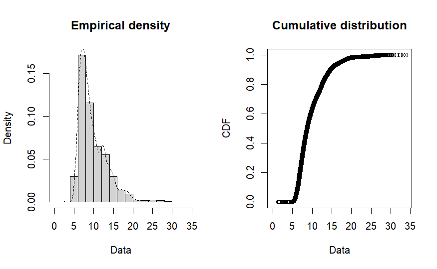

```r
# Graficar un histograma y la función de probabilidad acumulada
plotdist(x, histo = TRUE, demp = TRUE)
```

A priori, podemos presentar como candidatas distribuciones asímetricas, con gráficas con una concentración en la parte izquierda. Tenemos distribuciones tales como la Weibull, Gamma o Lognormal.

Ejecutemos el comando para realizar un gráfico de Cullen-Frey, para ver más información sobre su asimetría y curtosis, teniendo en cuenta la incertidumbre. En la gráfica también podremos ver 1000 muestreos de los datos a prueba.

```
summary statistics
------
min:  1.4   max:  33.77
median:  8.68
mean:  9.819868
estimated sd:  3.749467
estimated skewness:  1.634651
estimated kurtosis:  6.653829
```

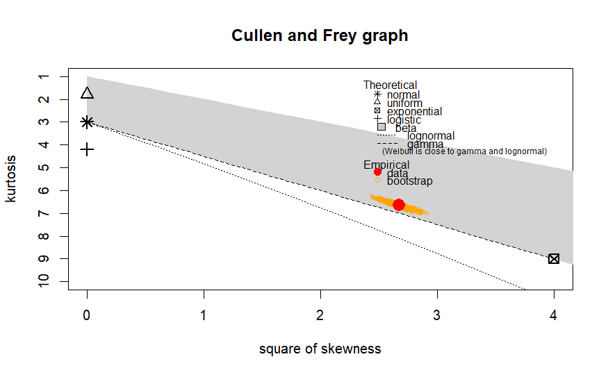

```r
# Ejecutar un gráfico Cullen-Frey
descdist(x, boot = 1000)
```

Gracias a la gráfica, podemos ver que los datos sí parecen distribuirse de una misma manera, viendo esto, las distribuciones que más parecen aproximarse son la distribución Gamma, Weibull, y un poco más lejos de los puntos de muestra la lognormal, por lo que esta última la descartaremos.

Ajustemos nuestros datos a ciertas distribuciones de probabilidad similares. Hemos elegido dos distribuciones para continuar, la Weibull y la Gamma.

```r
# Ajuste Weibull
ajuste_weibull <- suppressWarnings(fitdist(x, "weibull"))

# Ajuste Gamma
ajuste_gamma <- suppressWarnings(fitdist(x, "gamma"))

# Imprimir el resumen de los ajustes
summary(ajuste_weibull)
```

|  | estimate | Std. Error |
| --- | --- | --- |
| shape | 2.666924 | 0.01004182 |
| scale | 11.033861 | 0.02410236 |

```
Fitting of the distribution ' weibull ' by maximum likelihood
Parameters :
Loglikelihood:  -90515.89   AIC:  181035.8   BIC:  181052.6
Correlation matrix:
          shape     scale
shape 1.0000000 0.3405719
scale 0.3405719 1.0000000
```

```r
summary(ajuste_gamma)
```

|  | estimate | Std. Error |
| --- | --- | --- |
| shape | 8.3964096 | 0.063788274 |
| rate | 0.8550233 | 0.006693724 |

```
Fitting of the distribution ' gamma ' by maximum likelihood
Parameters :
Loglikelihood:  -86617.51   AIC:  173239   BIC:  173255.8
Correlation matrix:
          shape      rate
shape 1.0000000 0.9704126
rate  0.9704126 1.0000000
```

Gracias al ajuste, obtenemos los datos de los parámetros que aproximan las distribuciones teóricas frente a la distribución de nuetros datos de prueba.

Hemos obtenido valores para la log-verosimilitud, AIC, BIC y la matriz de correlación, comparando los resultados para ambas distribuciones, evidenciamos que la distribución Gamma, tiene valores mejores para log-verosimilitud, AIC y BIC.

- Gamma tiene un valor menos negativo (-86617.51) que la Weibull (-90515.89)
- Gamma tiene un valor menor de AIC (173239) que la Weibull (181035.8)
- Gamma tiene un valor menor de BIC (173255.8) que la Weibull (181052.6)

Grafiquemos la información suministrada por los ajustes para verlo mejor

```r
# Graficar los ajustes
plot(ajuste_weibull)
plot(ajuste_gamma)
```

[output not shown]

Grafiquemos ambos ajustes junto a nuestros datos

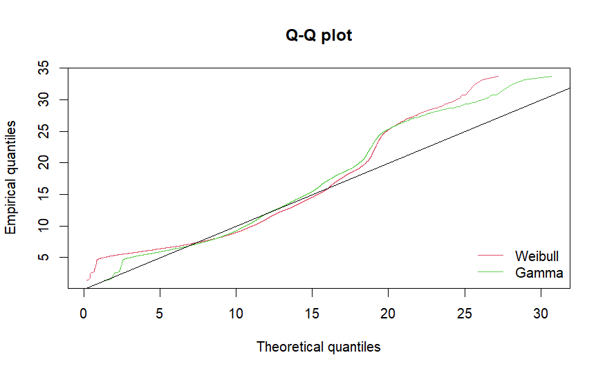

```r
# QQPlot
qqcomp(list(ajuste_weibull, ajuste_gamma),
       legendtext = c("Weibull", "Gamma"))
```

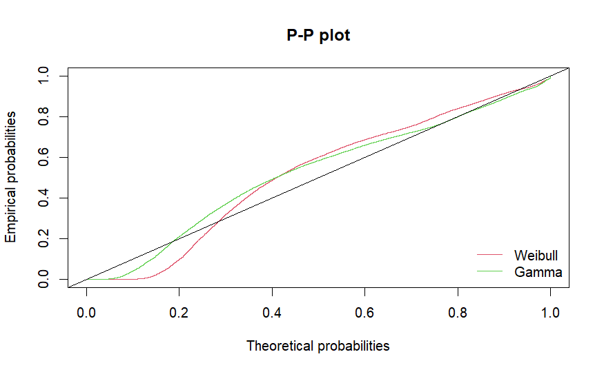

```r
# PPPlot
ppcomp(list(ajuste_weibull, ajuste_gamma),
       legendtext = c("Weibull", "Gamma"))
```

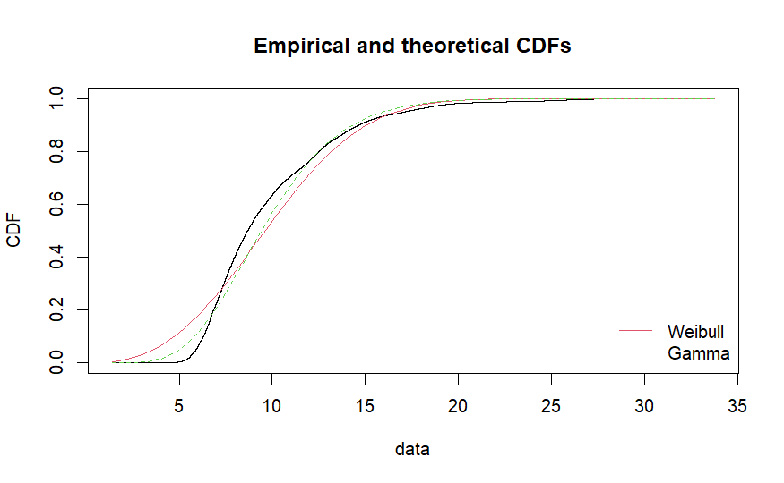

```r
# Comparación de CDF
cdfcomp(list(ajuste_weibull, ajuste_gamma),
        legendtext = c("Weibull", "Gamma"))
```

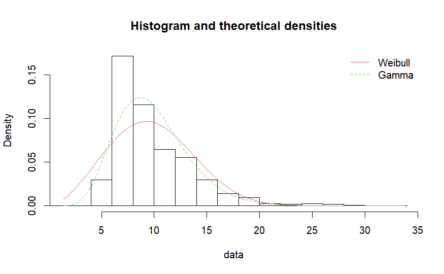

```r
# Comparación de Densidad
denscomp(list(ajuste_weibull, ajuste_gamma),
         legendtext = c("Weibull", "Gamma"))
```

Somos conscientes de que no hay mucha diferencia entre ambos ajustes. Asimismo, notamos la disparidad de estos en las gráficas q-q y p-p en los extremos. No tenemos información muy concluyente por ahora. Procedamos con una prueba más contundente para estos ajustes.

Evaluemos el ajuste de los datos, a las distribuciones Weibull y Gamma, calculando las estadísticas de bondad de ajuste de distintas pruebas.

```r
# Comparación de bondad de ajuste (AIC, BIC, etc.)
gofstat(list(ajuste_weibull, ajuste_gamma))
```

```
Goodness-of-fit statistics
                             1-mle-weibull  2-mle-gamma
Kolmogorov-Smirnov statistic     0.1272904   0.09351482
Cramer-von Mises statistic     168.7226605  95.38659238
Anderson-Darling statistic    1069.1917050 554.65743932

Goodness-of-fit criteria
                               1-mle-weibull 2-mle-gamma
Akaike's Information Criterion      181035.8    173239.0
Bayesian Information Criterion      181052.6    173255.8
```

Observamos que la distribución Gamma es el modelo que minimiza los criterios de información, pues tiene estadísticos menores en todas las pruebas en comparación a la distribución Weibull, además de lo ya mencionado, mejores valores de AIC y BIC.

Evidenciamos que tiene un menor estadístico en la prueba de Kolmogorov-Smirnov. Por lo que plateemos nuestras hipótesis para evaluarlo mejor:

Hipótesis:

H0 (nula): Los datos siguen la distribución Gamma. H1 (alternativa): Los datos no siguen esa distribución.

```r
# Ejecutar un test de Kolmogorov-Smirnov
ks_result <- suppressWarnings(ks.test(x, "pgamma", shape = ajuste_gamma$estimate["shape"],
                             rate = ajuste_gamma$estimate["rate"]))
ks_result
```

```
    Asymptotic one-sample Kolmogorov-Smirnov test

data:  x
D = 0.093515, p-value < 2.2e-16
alternative hypothesis: two-sided
```

Podemos observar un valor-p extremadamente bajo, por lo que podemos pensar que está sesgado. No debería tomarse como concluyente en este contexto porque los parámetros de la distribución Gamma que hemos probado fueron estimados a partir de los mismos datos que se están evaluando. Por lo tanto, y dado a este valor-p, es muy probable que los datos no sigan esta distribución.

Viendo esto, también podemos decir que tampoco siguen la distribución Weibull, evidentemente más dispar frente a nuestros datos, y con un estadístico de prueba en la Kolmogorov-Smirnov mayor.

Conclusión:

Sin embargo, los resultados de la prueba de Kolmogorov–Smirnov indican posibles disparidades con los modelos ajustados, lo que sugiere que los datos podrían no seguir una única distribución conocida. Esto puede deberse a:

Datos que estén correlacionados, contengan subpoblaciones o similares Varias distribuciones combinadas Estén sesgados, mal registrados o con valores redondeados

A pesar de estas limitaciones, el gran tamaño muestral aportaba una ventaja. En este contexto, la distribución Gamma puede ser utilizada como una aproximación razonable, pero es de considerar, que es una aproximación muy burda y poco confiable